# Final Project

Student: Daytonna Anderson

2026-05-06

## 1. Data

```r
data("wildfire")

wildfire <- wildfire %>%
  clean_names()

glimpse(wildfire)
```

```
## Rows: 14,609
## Columns: 11
## $ burnt_area <dbl> 0, 0, 0, 0, 0, 0, 0, 0, 0, 0, 0, 0, 0, 0, 0, 0, 0, 0, 0, 0,…
## $ dsr        <dbl> 0.21199875, 0.30435486, 0.20406335, 0.19731392, 0.20655645,…
## $ fwi        <dbl> 1.9933842, 2.6409558, 2.1545397, 2.1686053, 2.1404615, 2.55…
## $ bui        <dbl> 12.415579, 13.011121, 13.666483, 14.223325, 14.377093, 14.7…
## $ isi        <dbl> 1.3590981, 1.8078548, 1.5400054, 1.6465534, 1.4155348, 1.71…
## $ ffmc       <dbl> 60.80053, 70.49201, 76.52899, 79.22646, 73.75497, 75.27151,…
## $ dmc        <dbl> 8.794747, 9.289562, 9.879625, 10.368345, 10.464511, 10.7525…
## $ dc         <dbl> 64.81567, 65.78114, 66.74924, 67.64764, 68.15888, 68.92716,…
## $ day        <dbl> 1, 2, 3, 4, 5, 6, 7, 8, 9, 10, 11, 12, 13, 14, 15, 16, 17, …
## $ month      <fct> Jan, Jan, Jan, Jan, Jan, Jan, Jan, Jan, Jan, Jan, Jan, Jan,…
## $ year       <chr> "1980", "1980", "1980", "1980", "1980", "1980", "1980", "19…
```

| Column | Meaning |
| --- | --- |
| Burnt Area (`burnt_area`) | Daily burnt area in hectares |
| Fire Weather Index (`fwi`) | Numeric rating of fire intensity |
| Buildup Index (`bui`) | Numeric rating of fuel available for combustion |
| Initial Spread Index (`isi`) | Numeric rating of expected rate of fire spread |
| Fine Fuel Moisture Code (`ffmc`) | Numeric rating of moisture content of litter and other fuels |
| Daily Severity Rating (`dsr`) | Numeric rating of difficulty to control fires |
| Duff Moisture Code (`dmc`) | Numeric rating of average moisture content of lose compact organic layers |
| Drought Code (`dc`) | Rating of average moisture content of compact organic layers |
| `day`, `month`, `year` | Time stamp for each point |

## 2. Questions and Variables

#### Main Question

How do environmental conditions influence the daily total burned area at the national scale?

#### Variables

Response Variable: `burnt_area` Predictor Variable(s): `fwi`, `isi`, `bui`, `dc`

#### Comparison Groups

- High vs. low fire risk days (`fwi`)
- High vs. low fuel availability (`bui`)
- Seasonal comparisons using `month`

#### Hypothesis

Hypothesized results:

- $H_0$: Burnt area has no significant relationship with FWI, ISI, BUI, and DC
- $H_A$: Burnt area has a significant relationship with at least one of FWI, ISI, BUI, and DC

## 3. Initial Data Exploration

```r
wildfire %>%
  summarize(
    total_days = n(),
    zero_burn_days = sum(burnt_area == 0, na.rm = TRUE),
   nonzero_burn_days = sum(burnt_area > 0, na.rm = TRUE)
  )
```

| total_days | zero_burn_days | nonzero_burn_days |
| --- | --- | --- |
| 14609 | 3642 | 10967 |

Here I summarize the data into two categories: days with fire and days without fire (1 or 0). With the amount of zeros, this justifies the need for transformation in the data to make it work with normal tests.

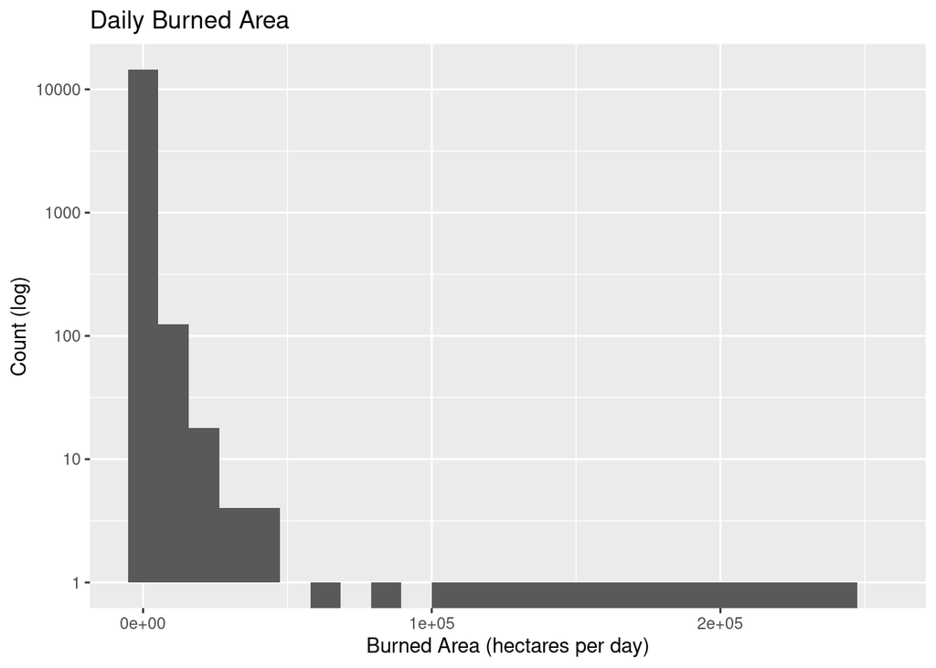

```r
wildfire <- wildfire %>%
  mutate(log_burn = log10(burnt_area +1))
```

This original plot is highly right-skewed (positively skewed), meaning I cannot use normal testing and explains the need to transform the data from the few extreme fire days within the dataset. I used log scaling to center the data more, since it handles the zeros which ends up reducing the skewed aspect.

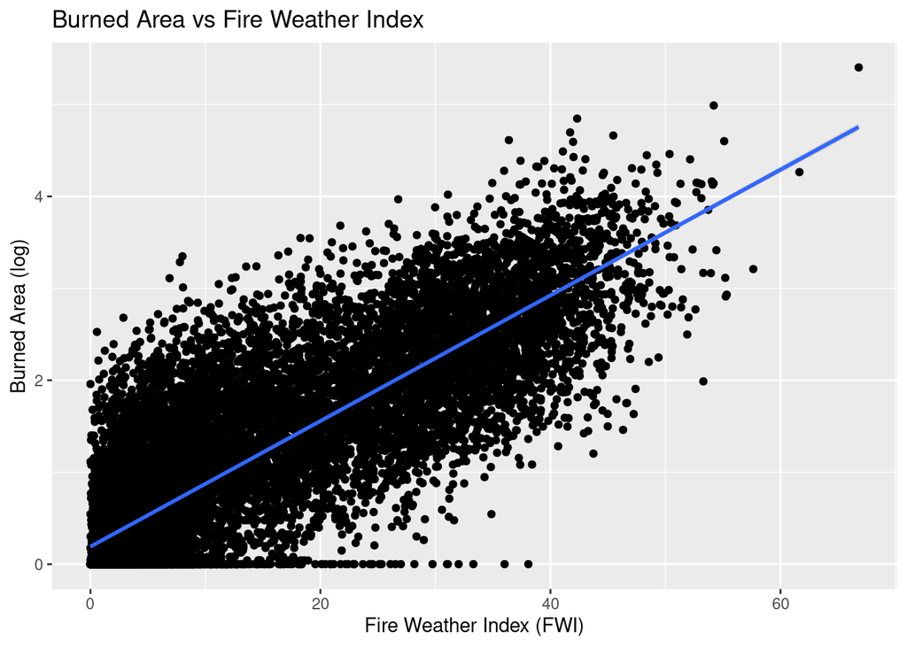

[figure not shown]

[figure not shown]

[figure not shown]

We can now see a clear positive trend with the response variable and each predictor variables, which supports regression modeling. Meaning that when the predictor variable increases, so does the response variable.

## 4. Exploratory Variable Testing

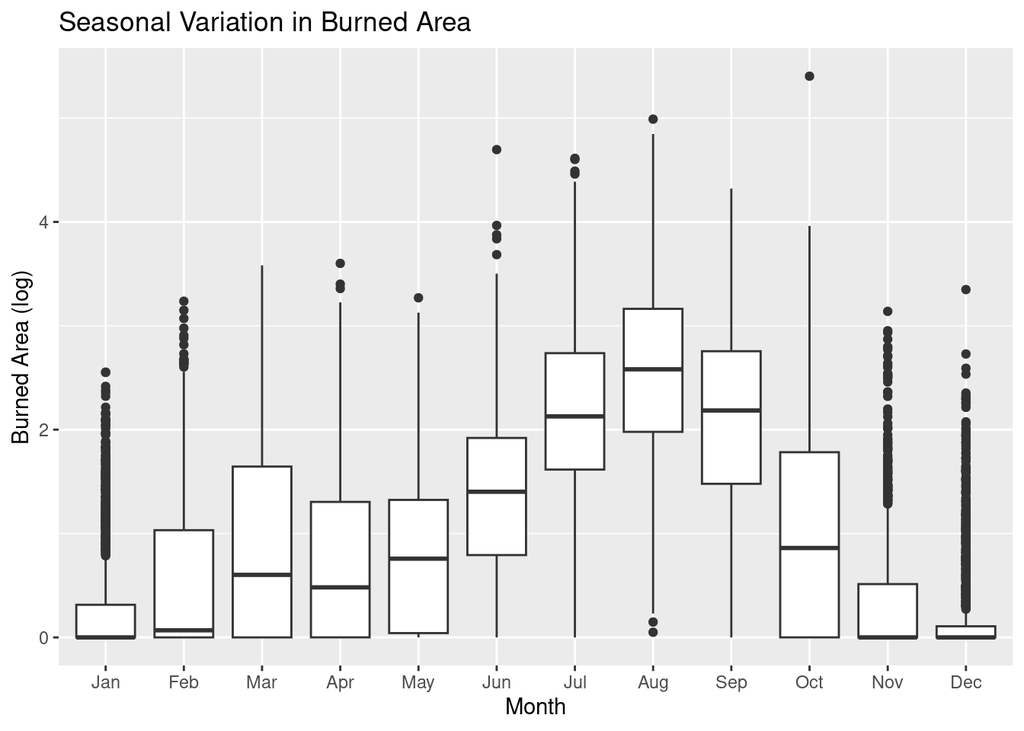

We see variability through the months, with a peak wildfire count in august and the months leading up to and following it. This suggests that summertime in Portugal harbors the influencial conditions for wildfires.

```r
wildfire <- wildfire %>%
  mutate(
    fwi_group = if_else(fwi > median(fwi, na.rm = TRUE),
                        "High FWI", "Low FWI")
  )
```

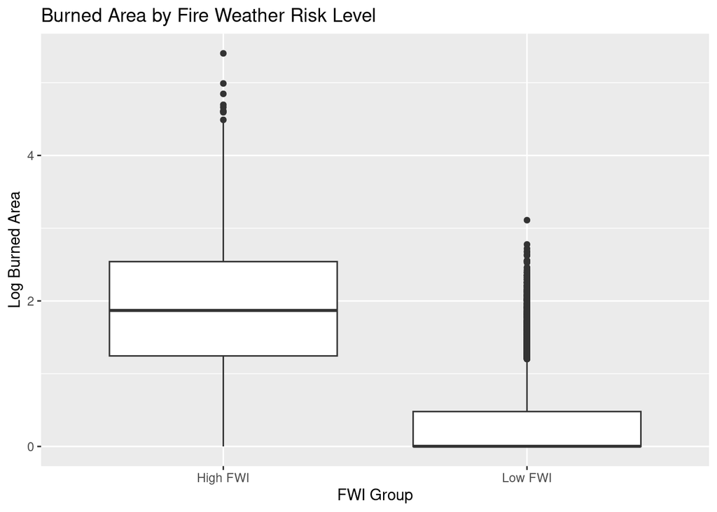

We see a significant difference between High `fwi` and low `fwi`, with higher rates increasing the area burned.

```r
wildfire <- wildfire %>%
  mutate(
    bui_group = if_else(bui > median(bui, na.rm = TRUE),
                        "High BUI", "Low BUI")
  )
```

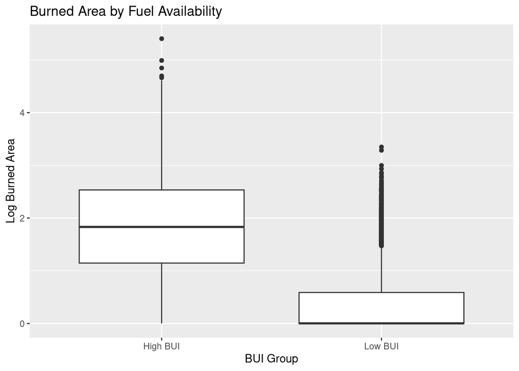

Similar to `fwi`, `bui` follows the same trend with high rates increasing the area burned. Meaning, that area burned is influenced by the amount of fuel available.

## 5. Statistical Testing

```
##
##  One Sample t-test
##
## data:  wildfire$burnt_area
## t = 14.205, df = 14608, p-value < 2.2e-16
## alternative hypothesis: true mean is not equal to 0
## 95 percent confidence interval:
##  280.0369 369.6919
## sample estimates:
## mean of x
##  324.8644
```

```
##
## Call:
## lm(formula = log10(burnt_area + 1) ~ fwi + isi + bui + dc, data = wildfire)
##
## Residuals:
##      Min       1Q   Median       3Q      Max
## -2.86459 -0.33727 -0.08637  0.32991  2.53709
##
## Coefficients:
##               Estimate Std. Error t value Pr(>|t|)
## (Intercept) -1.140e-02  1.076e-02  -1.059    0.289
## fwi          8.967e-03  2.272e-03   3.947 7.96e-05 ***
## isi          1.319e-01  5.392e-03  24.459  < 2e-16 ***
## bui          4.293e-03  2.081e-04  20.624  < 2e-16 ***
## dc           4.074e-04  4.856e-05   8.390  < 2e-16 ***
## ---
## Signif. codes:  0 '***' 0.001 '**' 0.01 '*' 0.05 '.' 0.1 ' ' 1
##
## Residual standard error: 0.5722 on 14604 degrees of freedom
## Multiple R-squared:  0.7236, Adjusted R-squared:  0.7235
## F-statistic:  9558 on 4 and 14604 DF,  p-value: < 2.2e-16
```

This model explores the combined effects of each environmental response variable. The R-squared value of 0.72 explains that 72% of the wildfire variability is explained by environmental conditions.

The 2.2e-16 p-value means we reject our null hypothesis, which explains that burnt area has a significant relationship with at least one of fwi, isi, bui, and dc.

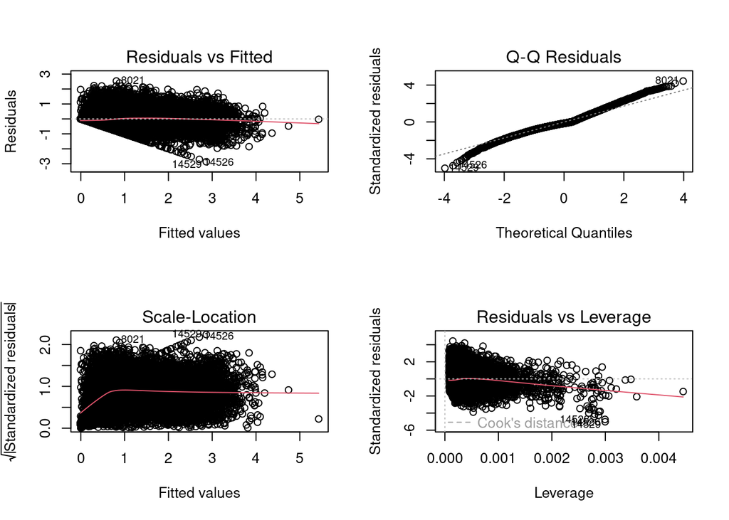

With the residual models:

```r
wildfire <- wildfire %>%
  mutate(residuals = resid(model),
         fitted = fitted(model))
```

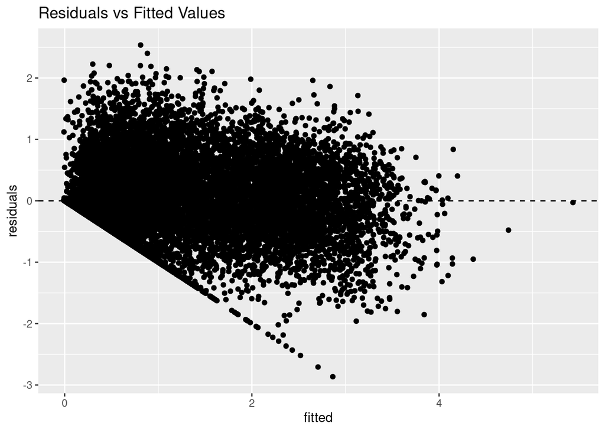